# Assignment 3: Verify the Claim

- Show All Code
- Hide All Code
- View Source

Testing a published claim about neighborhood change against the data behind it

Author

Chloe Alimurong

Published

September 11, 2026

## Part 1: Introduction

In the article, “New Census figures on Philly neighborhoods show inequality, high numbers of whites living in poverty” by Alfred Lubrano for the Philadelphia Media Network, Lubrano reports on the American Community Survey’s 5-year estimate for 2013 to reveal a growing number of white people living in poverty in Philadelphia’s neighborhoods. Fairhill being the prime example, he uses this to describe how white people in the area have struggled to recover from the recession and face addiction. Also, noting that Eastwick faces a higher number of people living in poverty, the article suggested low-income African immigrants are to explain for this change. A number of factors contribute to the poverty crisis in Philadelphia. My report will attempt to evaluate and validate this poverty rate change at the tract-level. I will be analyizing the following variables mentioned in the article; poverty rate(count of people with poverty status;B17001_002 divided by the total population for people with poverty status; B17001_001) and population (B01003_001). I will be using numbers from the 5-year estimate for 2006-2010 and 2013-2017, the same years the article used in comparison to make different points on the change in poverty rates in Philadelphia. As the article does not explicitly define the ACS variables they used, I will continue this report under the assumption that ‘poverty rates’ are the percent of people that fall below poverty level not separated by gender or age.

## Part 2: Code

```r
#Computing the poverty rate

tract_2010 <- get_acs(
  geography = "tract",
  variables = c(poverty_below = "B17001_002", poverty_total = "B17001_001"),
  state = "PA", county = "Philadelphia",
  year = 2010, survey = "acs5",
  output = "wide"
)

tract_2017 <- get_acs(
  geography = "tract",
  variables = c(poverty_below = "B17001_002", poverty_total = "B17001_001"),
  state = "PA", county = "Philadelphia",
  year = 2017, survey = "acs5",
  output = "wide"
)

tract_2010 <- tract_2010 %>%
  mutate(
    rate = poverty_belowE/poverty_totalE,
    rate_moe = moe_prop(poverty_belowE, poverty_totalE, poverty_belowM, poverty_totalM)
  )

tract_2017 <- tract_2017 %>%
  mutate(
    rate = poverty_belowE/poverty_totalE,
    rate_moe = moe_prop(poverty_belowE, poverty_totalE, poverty_belowM, poverty_totalM)
  )

#Computing the Coefficient of Variation & Flag reliability (Jurjevich et al. (2018))
reliability_table_2010 <- tract_2010 %>%
  mutate(
    cv = (rate_moe / 1.645) / rate * 100,
    dot = case_when(
      cv < 12  ~ "🟢",
      cv <= 40 ~ "🟡",
      TRUE     ~ "🔴"
    ),
    flag = case_when(
      cv < 12  ~ "Reliable",
      cv <= 40 ~ "Somewhat reliable",
      TRUE     ~ "Unreliable"
    ),
    NAME = str_remove(NAME, ", Philadelphia County, Pennsylvania")
  ) %>%
  arrange(desc(cv)) %>%
  select(dot, NAME, rate, rate_moe, cv, flag)

reliability_table_2017 <- tract_2017 %>%
  mutate(
    cv = (rate_moe/1.645)/rate*100,
    dot = case_when(
      cv <12 ~ "🟢",
      cv <=40 ~ "🟡",
      TRUE ~ "🔴"
    ),
    flag = case_when(
      cv <12 ~ "Reliable",
      cv <= 40 ~"Somewhat reliable",
      TRUE ~ "Unreliable"
    ),
    NAME = str_remove(NAME, ", Philadelphia County, Pennsylvania")
  )%>%
  arrange(desc(cv))%>%
  select(dot, NAME, rate, rate_moe, cv, flag)

reliability_table_2010 %>%
  gt() %>%
  fmt_percent(columns = c(rate, rate_moe), decimals = 0) %>%
  fmt_number(columns = cv, decimals = 1) %>%
  cols_label(
    dot      = "",
    NAME     = "County",
    rate = "Poverty Rate Estimate",
    rate_moe      = "Poverty Rate MOE",
    cv       = "CV (%)",
    flag     = "Reliability"
  ) %>%
  cols_align(align = "center", columns = dot) %>%
  tab_header(
    title    = "Poverty Rate Estimates and Reliability ranked by Coefficient of Variation",
    subtitle = "Philadelphia tracts, ACS 2010 5-year estimates"
  ) %>%
  tab_source_note(
    "Reliability thresholds follow Jurjevich et al. (2018): CV < 12% reliable, 12–40% somewhat reliable, > 40% unreliable."
  )
```

Poverty Rate Estimates and Reliability ranked by Coefficient of Variation

Philadelphia tracts, ACS 2010 5-year estimates

|  | County | Poverty Rate Estimate | Poverty Rate MOE | CV (%) | Reliability |
| --- | --- | --- | --- | --- | --- |
| 🔴 | Census Tract 231 | 0% | 10% | Inf | Unreliable |
| 🔴 | Census Tract 9801 | 0% | 163% | Inf | Unreliable |
| 🔴 | Census Tract 9806 | 10% | 14% | 85.5 | Unreliable |
| 🔴 | Census Tract 235 | 5% | 6% | 71.6 | Unreliable |
| 🔴 | Census Tract 236 | 10% | 12% | 70.8 | Unreliable |
| 🔴 | Census Tract 10.01 | 2% | 3% | 70.4 | Unreliable |
| 🔴 | Census Tract 366 | 3% | 3% | 68.1 | Unreliable |
| 🔴 | Census Tract 348.01 | 10% | 11% | 66.4 | Unreliable |
| 🔴 | Census Tract 9802 | 22% | 23% | 63.2 | Unreliable |
| 🔴 | Census Tract 15 | 7% | 8% | 62.0 | Unreliable |
| 🔴 | Census Tract 385 | 7% | 7% | 59.6 | Unreliable |
| 🔴 | Census Tract 387 | 9% | 8% | 55.1 | Unreliable |
| 🔴 | Census Tract 220 | 4% | 3% | 55.0 | Unreliable |
| 🔴 | Census Tract 386 | 8% | 7% | 54.8 | Unreliable |
| 🔴 | Census Tract 337.02 | 7% | 7% | 54.4 | Unreliable |
| 🔴 | Census Tract 384 | 1% | 1% | 54.1 | Unreliable |
| 🔴 | Census Tract 10.02 | 10% | 9% | 53.9 | Unreliable |
| 🔴 | Census Tract 143 | 8% | 7% | 52.7 | Unreliable |
| 🔴 | Census Tract 258 | 7% | 6% | 52.4 | Unreliable |
| 🔴 | Census Tract 365.02 | 2% | 2% | 51.4 | Unreliable |
| 🔴 | Census Tract 342 | 7% | 6% | 50.9 | Unreliable |
| 🔴 | Census Tract 356.02 | 8% | 7% | 50.6 | Unreliable |
| 🔴 | Census Tract 61 | 13% | 11% | 49.2 | Unreliable |
| 🔴 | Census Tract 339 | 5% | 4% | 49.1 | Unreliable |
| 🔴 | Census Tract 27.02 | 10% | 8% | 48.3 | Unreliable |
| 🔴 | Census Tract 136.01 | 3% | 2% | 47.3 | Unreliable |
| 🔴 | Census Tract 353.02 | 9% | 6% | 44.9 | Unreliable |
| 🔴 | Census Tract 363.02 | 11% | 8% | 44.8 | Unreliable |
| 🔴 | Census Tract 358 | 4% | 3% | 44.8 | Unreliable |
| 🔴 | Census Tract 331.02 | 20% | 15% | 44.6 | Unreliable |

[output cut: 354 more lines]

Reliability thresholds follow Jurjevich et al. (2018): CV < 12% reliable, 12–40% somewhat reliable, > 40% unreliable.

```r
reliability_table_2017 %>%
  gt() %>%
  fmt_percent(columns = c(rate, rate_moe), decimals = 0) %>%
  fmt_number(columns = cv, decimals = 1) %>%
  cols_label(
    dot      = "",
    NAME     = "Tract",
    rate = "Poverty Rate Estimate",
    rate_moe      = "Poverty Rate MOE",
    cv       = "CV (%)",
    flag     = "Reliability"
  ) %>%
  cols_align(align = "center", columns = dot) %>%
  tab_header(
    title    = "Poverty Rate Estimates and Reliability ranked by Coefficient of Variation",
    subtitle = "Philadelphia tracts, ACS 2017 5-year estimates"
  ) %>%
  tab_source_note(
    "Reliability thresholds follow Jurjevich et al. (2018): CV < 12% reliable, 12–40% somewhat reliable, > 40% unreliable."
  )
```

Poverty Rate Estimates and Reliability ranked by Coefficient of Variation

Philadelphia tracts, ACS 2017 5-year estimates

|  | Tract | Poverty Rate Estimate | Poverty Rate MOE | CV (%) | Reliability |
| --- | --- | --- | --- | --- | --- |
| 🔴 | Census Tract 9891 | 92% | 220% | 144.9 | Unreliable |
| 🔴 | Census Tract 9800 | 5% | 7% | 85.6 | Unreliable |
| 🔴 | Census Tract 231 | 1% | 1% | 66.7 | Unreliable |
| 🔴 | Census Tract 256 | 4% | 4% | 64.7 | Unreliable |
| 🔴 | Census Tract 9801 | 13% | 13% | 61.5 | Unreliable |
| 🔴 | Census Tract 386 | 3% | 3% | 59.3 | Unreliable |
| 🔴 | Census Tract 9802 | 11% | 10% | 51.4 | Unreliable |
| 🔴 | Census Tract 340 | 10% | 8% | 47.9 | Unreliable |
| 🔴 | Census Tract 347.02 | 2% | 2% | 47.1 | Unreliable |
| 🔴 | Census Tract 10.02 | 6% | 5% | 46.7 | Unreliable |
| 🔴 | Census Tract 220 | 1% | 1% | 45.4 | Unreliable |
| 🔴 | Census Tract 363.03 | 6% | 4% | 44.2 | Unreliable |
| 🔴 | Census Tract 29 | 18% | 13% | 43.4 | Unreliable |
| 🔴 | Census Tract 341 | 10% | 7% | 42.4 | Unreliable |
| 🔴 | Census Tract 365.01 | 13% | 9% | 42.2 | Unreliable |
| 🔴 | Census Tract 8.01 | 14% | 10% | 41.9 | Unreliable |
| 🔴 | Census Tract 4.02 | 4% | 3% | 41.5 | Unreliable |
| 🔴 | Census Tract 236 | 10% | 7% | 41.1 | Unreliable |
| 🔴 | Census Tract 366 | 5% | 3% | 40.6 | Unreliable |
| 🔴 | Census Tract 356.02 | 2% | 2% | 40.3 | Unreliable |
| 🔴 | Census Tract 235 | 9% | 6% | 40.0 | Unreliable |
| 🔴 | Census Tract 365.02 | 7% | 4% | 40.0 | Unreliable |
| 🟡 | Census Tract 352 | 6% | 4% | 40.0 | Somewhat reliable |
| 🟡 | Census Tract 10.01 | 6% | 4% | 39.9 | Somewhat reliable |
| 🟡 | Census Tract 40.02 | 7% | 5% | 39.5 | Somewhat reliable |
| 🟡 | Census Tract 12.01 | 3% | 2% | 39.4 | Somewhat reliable |
| 🟡 | Census Tract 385 | 7% | 5% | 39.2 | Somewhat reliable |
| 🟡 | Census Tract 344 | 5% | 3% | 38.6 | Somewhat reliable |
| 🟡 | Census Tract 362.03 | 5% | 3% | 38.5 | Somewhat reliable |
| 🟡 | Census Tract 361 | 14% | 9% | 38.5 | Somewhat reliable |

[output cut: 354 more lines]

Reliability thresholds follow Jurjevich et al. (2018): CV < 12% reliable, 12–40% somewhat reliable, > 40% unreliable.

```r
#Computing the change and change MOE between 2010 and 2017
get_poverty <- function(yr) {
  get_acs(
    geography = "tract",
    variables = "B07012_002",
    state     = "PA",
    county = "Philadelphia",
    year      = yr,
    survey    = "acs5"
  ) %>%
    mutate(period = paste0(yr - 4, "-", yr))
}

poverty_change <- bind_rows(
  get_poverty(2010),
  get_poverty(2017)
)

poverty_wide <- poverty_change %>%
  select(GEOID, NAME, period, estimate, moe) %>%
  pivot_wider(
    names_from  = period,
    values_from = c(estimate, moe)
  )

# 90% confidence significance test
rate_tested <- tract_2010 %>%
  select(GEOID, NAME, rate_2010 = rate, moe_2010 = rate_moe) %>%
  left_join(
    tract_2017 %>% select(GEOID, rate_2017 = rate, moe_2017 = rate_moe),
    by = "GEOID"
  ) %>%
  mutate(
    change      = rate_2017 - rate_2010,
    se_1        = moe_2010 / 1.645,
    se_2        = moe_2017 / 1.645,
    se_diff     = sqrt(se_1^2 + se_2^2),
    moe_diff    = se_diff * 1.645,
    z           = change / se_diff,
    significant = abs(z) > 1.645
  )

rate_tested %>% count(significant)
```

```
# A tibble: 3 × 2
  significant     n
  <lgl>       <int>
1 FALSE         313
2 TRUE           63
3 NA              8
```

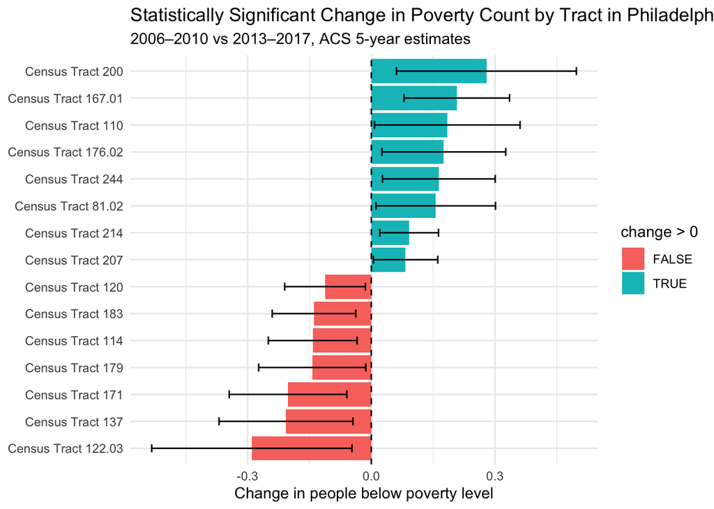

```r
rate_tested %>%
  filter(!is.na(significant)) %>%
  filter(significant) %>%
  slice_head(n=15) %>%
  mutate(NAME = str_remove(NAME, ", Philadelphia County, Pennsylvania")) %>%
  ggplot(aes(x = reorder(NAME, change), y = change)) +
  geom_col(aes(fill = change > 0)) +
  geom_errorbar(aes(ymin = change - moe_diff,
                    ymax = change + moe_diff), width = 0.3) +
  geom_hline(yintercept = 0, linetype = "dashed") +
  coord_flip() +
  theme_minimal() +
  labs(title = "Statistically Significant Change in Poverty Count by Tract in Philadelphia",
       subtitle = "2006–2010 vs 2013–2017, ACS 5-year estimates",
       x = NULL, y = "Change in people below poverty level")
```

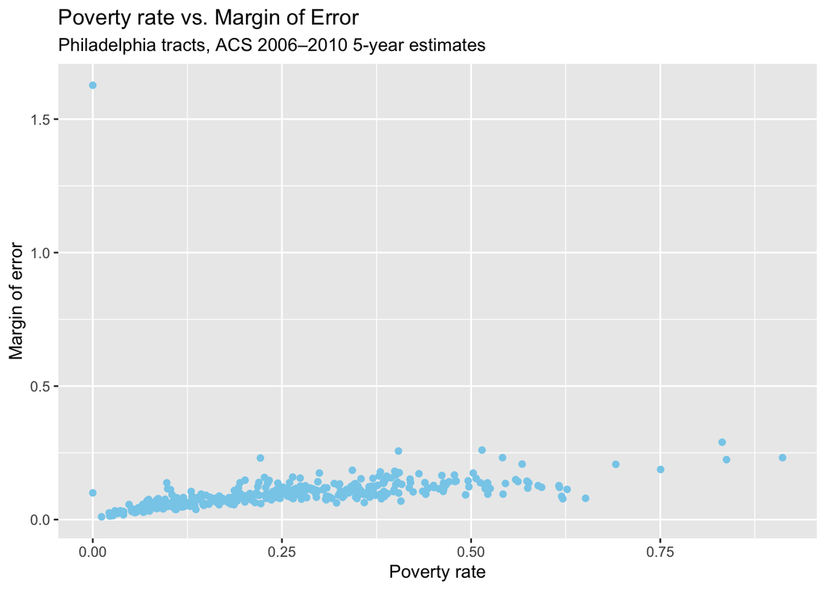

```r
# Other charts
ggplot(tract_2010)+
  aes(x=rate, y = rate_moe)+
  geom_point(color = "skyblue")+
  labs(
    title = "Poverty rate vs. Margin of Error",
    subtitle = "Philadelphia tracts, ACS 2006–2010 5-year estimates",
    x = "Poverty rate",
    y = "Margin of error"
  )
```

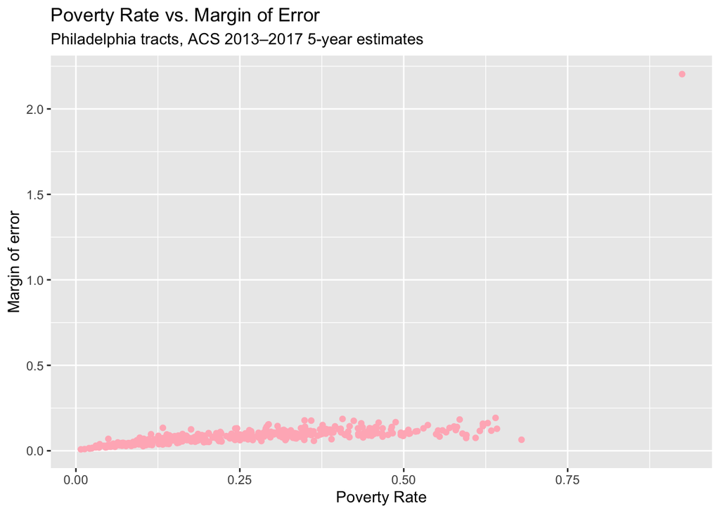

```r
ggplot(tract_2017)+
  aes(x=rate, y = rate_moe)+
  geom_point(color = "lightpink")+
  labs(
    title = "Poverty Rate vs. Margin of Error",
    subtitle = "Philadelphia tracts, ACS 2013–2017 5-year estimates",
    x = "Poverty Rate",
    y = "Margin of error"
  )
```

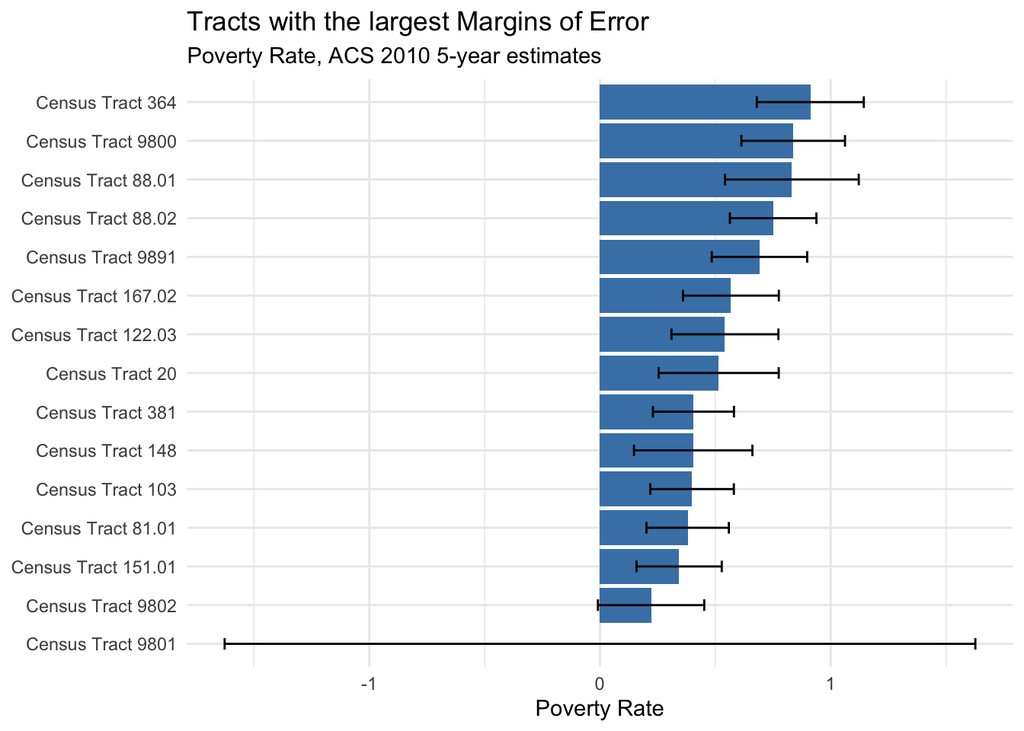

```r
tract_2010 %>%
  filter(!is.na(rate)) %>%
  arrange(desc(rate_moe)) %>%
  mutate(NAME = str_remove(NAME, ", Philadelphia County, Pennsylvania")) %>%
  slice_head(n = 15) %>%
  ggplot(aes(x = reorder(NAME, rate), y = rate)) +
  geom_col(fill = "steelblue") +
  geom_errorbar(aes(ymin = rate - rate_moe, ymax = rate + rate_moe), width = 0.3) +
  coord_flip() +
  theme_minimal() +
  scale_y_continuous(labels = scales::comma) +
  labs(
    title = "Tracts with the largest Margins of Error",
    subtitle = "Poverty Rate, ACS 2010 5-year estimates",
    x = NULL,
    y = "Poverty Rate"
  )
```

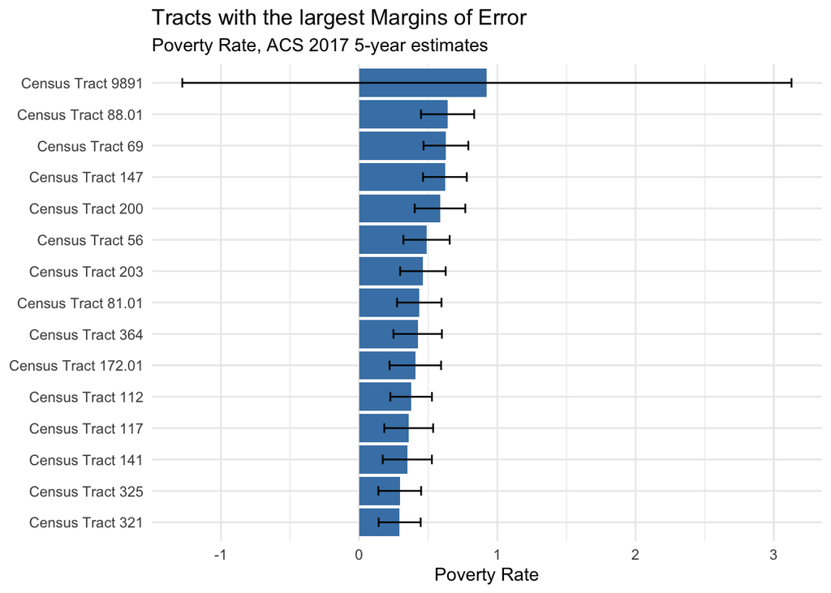

```r
tract_2017 %>%
  filter(!is.na(rate)) %>%
  arrange(desc(rate_moe)) %>%
  mutate(NAME = str_remove(NAME, ", Philadelphia County, Pennsylvania")) %>%
  slice_head(n = 15) %>%
  ggplot(aes(x = reorder(NAME, rate), y = rate)) +
  geom_col(fill = "steelblue") +
  geom_errorbar(aes(ymin = rate - rate_moe, ymax = rate + rate_moe), width = 0.3) +
  coord_flip() +
  theme_minimal() +
  scale_y_continuous(labels = scales::comma) +
  labs(
    title = "Tracts with the largest Margins of Error",
    subtitle = "Poverty Rate, ACS 2017 5-year estimates",
    x = NULL,
    y = "Poverty Rate"
  )
```

```r
# Population
tract_2017_pop <- get_acs(
  geography = "tract",
  variables = "B01003_001",
  state= "PA",
  county= "Philadelphia",
  year= 2017,
  survey = "acs5",
  output ="wide"
)


tract_2017_pop[tract_2017_pop$B01003_001E == "0", ]
```

```
# A tibble: 8 × 4
  GEOID       NAME                                       B01003_001E B01003_001M
  <chr>       <chr>                                            <dbl>       <dbl>
1 42101005000 Census Tract 50, Philadelphia County, Pen…           0          10
2 42101980300 Census Tract 9803, Philadelphia County, P…           0          10
3 42101980400 Census Tract 9804, Philadelphia County, P…           0          10
4 42101980500 Census Tract 9805, Philadelphia County, P…           0          10
5 42101980600 Census Tract 9806, Philadelphia County, P…           0          10
6 42101980700 Census Tract 9807, Philadelphia County, P…           0          10
7 42101980800 Census Tract 9808, Philadelphia County, P…           0          10
8 42101980900 Census Tract 9809, Philadelphia County, P…           0          10
```

## Part 3: Which claims do I support

The article makes numerous claims that can and cannot be backed by this replication. 1. The overall claim that poverty across the city has risen in 2013-2017 from 2006-2010 appears to be supported in that the average rate of poverty in the 2013-2017 estimate is truly 26.1% and is higher in comparison to the rate for 2006-2010 at 25.5%. 2. This replication study does not support the article’s claim that poverty rates in 22 majority-white neighborhoods have increased, dramatically in some. This is largely due to the fact that 16% of the tracts (63 out of 384) show statistically significant change with 90% confidence. This study as is does not determine which neighborhoods that number encompasses or if there was a large, dramatic increase in poverty rates. It also does not support the claim that neighborhoods surrounding the Philadelphia International Airport has the highest poverty rate increase of any community, it reveals NA due to lack of populace.  
3. We cannot determine in this replication backs any claim about neighborhood poverty rates, race-based poverty rates, or that any other demographic influencing poverty has a statistically significant effect on poverty rates. Doing so would require a different filter on ACS data and include a study on more variables, such as median income, and their significance. We do not know the exact variables they used to determine the proportion of white people in Fairhill and most explanatory variables such as immigration status and employment mentioned in the article were collected through testimony and qualitatively.

## Part 4 Rewriting the central paragraph

> Being released on Thursday, the U.S. Census Bureau‘s American Community Survey (ACS) Five-Year Estimate for 2013 through 2017 takes a microscope to the city’s formidable 26 percent poverty rate, revealing fault lines of distress and hardship. For example: Fairhill in North Philadelphia registered a stunning 61 percent poverty rate. The neighborhood of Eastwick in Southwest Philadelphia, near Philadelphia International Airport, showed the greatest poverty-rate increase of any community, rocketing from 12 percent during 2006-10 to 26 percent in the newest survey. That means that even after the recession ended, around a decade ago, conditions in Eastwick have gotten much worse than during the depth of the downturn. White poverty throughout much of the city skyrocketed, led by the Northeast neighborhood of Holmesburg, which went from a 2 percent poverty rate to 19 percent. The median household income of Tioga-Nicetown plummeted from $28,026 to $17,493, the largest drop in the city.

```
# A tibble: 1 × 4
  mean_rate median_rate min_rate max_rate
      <dbl>       <dbl>    <dbl>    <dbl>
1     0.255       0.229        0    0.912
```

```
# A tibble: 1 × 4
  mean_rate median_rate min_rate max_rate
      <dbl>       <dbl>    <dbl>    <dbl>
1     0.261       0.245  0.00756    0.925
```

Out of the 384 tracts tested in this study, 63 tracts showed a statistically significant change with 90% confidence while 313 (over 80% of the tracts) did not. Most of the census tracts in Philadelphia did not show a change in poverty rate distinguishable enough from statistical noise. For example: The highest rate of change in poverty was Census Tract 56, an increase in 35.67%. The total poverty rate being 48.76% in the 2017 5-year estimate.

```r
rate_tested %>%
  filter(significant) %>%
  arrange(desc(change)) %>%
  select(NAME, rate_2010, rate_2017, change, moe_diff) %>%
  slice_head(n = 10)
```

```
# A tibble: 10 × 5
   NAME                                      rate_2010 rate_2017 change moe_diff
   <chr>                                         <dbl>     <dbl>  <dbl>    <dbl>
 1 Census Tract 56, Philadelphia County, Pe…    0.131      0.488  0.357   0.189
 2 Census Tract 60, Philadelphia County, Pe…    0.0405     0.349  0.309   0.142
 3 Census Tract 2, Philadelphia County, Pen…    0.0719     0.376  0.304   0.139
 4 Census Tract 200, Philadelphia County, P…    0.306      0.585  0.279   0.218
 5 Census Tract 305.02, Philadelphia County…    0.0531     0.315  0.262   0.0876
 6 Census Tract 389, Philadelphia County, P…    0.134      0.353  0.218   0.143
 7 Census Tract 167.01, Philadelphia County…    0.276      0.483  0.207   0.128
 8 Census Tract 245, Philadelphia County, P…    0.385      0.590  0.204   0.132
 9 Census Tract 291, Philadelphia County, P…    0.274      0.467  0.193   0.140
10 Census Tract 110, Philadelphia County, P…    0.297      0.482  0.184   0.177
```

The areas near the Philadelphia International Airport have no change in poverty rates due to having a population of zero.

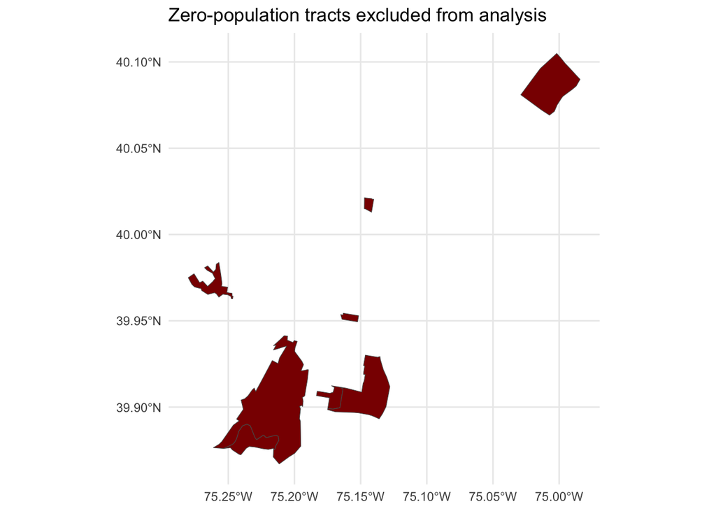

# References

Jurjevich, J. R., Griffin, A. L., Spielman, S. E., Folch, D. C., Merrick, M., & Nagle, N. N. (2018). Navigating statistical uncertainty: How urban and regional planners understand and work with American community survey (ACS) data for guiding policy. Journal of the American Planning Association, 84(2), 112-126.

Lubrano, Alfred. “New Census figures on Philly neighborhoods show inequality, high numbers of whites living in poverty.” WHYY / Philadelphia Inquirer, December 6, 2018. https://whyy.org/articles/new-census-figures-on-philly-neighborhoods-show-inequality-high-numbers-of-whites-living-in-poverty/